# Using SVM to build Democracy indicators

```python
#Importing libraries
import pandas as pd
import numpy as np
import matplotlib.pyplot as plt

import warnings
warnings.filterwarnings('ignore')
```

```python
#Importing the V-dem dataset
data_vdem = pd.read_csv("V-Dem-CY-Full+Others-v10.csv")
```

The variables that interest us from the v-dem dataset are: oppositions party autonomy (*v2psoppaut*), party ban (*v2psparban*), the percentage of adult population with legal right to vote (*v2asuffrage*), the percentage of enfranchised adults older than the minimal voting age (*v2elsuffrage*), and female suffrage (*v2fsuffrage*):

```python
data=data_vdem[["country_name","year","v2psoppaut","v2psparban","v2asuffrage","v2elsuffrage", "v2fsuffrage"]]
```

1. We first import the Polity dataset, and then select the democratic/autocratic observations
2. We add the label 1 or -1 to the country-year observations that are democratic or autocratic, respectively
3. Take the country-year observations that were selected and add their attributes; putting all this information in the same table (to further apply the SVM)

Importing data from the polity database:

```python
polity = pd.read_excel("politydata.xls")
```

## Building the priming dataset

Selecting country-year observations that are democratic:

```python
is_democracy= polity.polity2==10
democracy=polity[is_democracy]
onlydemo=democracy[["country","year"]]
```

Selecting country-year observations that are autocratic:

```python
is_autocracy=polity.polity2<=-9
autocracies=polity[is_autocracy]
onlyauto=autocracies[["country","year"]]
onlyauto
```

|  | country | year |
| --- | --- | --- |
| 145 | Afghanistan | 1945 |
| 146 | Afghanistan | 1946 |
| 147 | Afghanistan | 1947 |
| 148 | Afghanistan | 1948 |
| 149 | Afghanistan | 1949 |
| ... | ... | ... |
| 17502 | Zambia | 1986 |
| 17503 | Zambia | 1987 |
| 17504 | Zambia | 1988 |
| 17505 | Zambia | 1989 |
| 17506 | Zambia | 1990 |

2498 rows × 2 columns

Adding the labels 1 (democratic) or -1 (autocratic) for each selected country-year observation:

Creating the table with attributes and labels:

```python
#'Prussia', 'Yemen North' and 'Yugoslavia' do not appear in the v-dem dataset.
onlyauto.replace({'country': 'Congo Kinshasa'}, {'country': 'Democratic Republic of the Congo'}, inplace=True)
onlyauto.replace({'country': 'Myanmar (Burma)'}, {'country': 'Burma/Myanmar'}, inplace=True)
onlyauto.replace({'country': 'Cote D''Ivoire'}, {'country': 'Ivory Coast'}, inplace=True)
onlyauto.replace({'country': 'Cote D''Ivoire'}, {'country': 'United Arab Emirates'}, inplace=True)
onlyauto.replace({'country': 'Congo-Brazzaville'}, {'country': 'Republic of the Congo'}, inplace=True)
onlyauto.replace({'country': 'Korea North'}, {'country': 'North Korea'}, inplace=True)
onlyauto.replace({'country': 'Korea South'}, {'country': 'South Korea'}, inplace=True)
onlyauto.replace({'country': 'Sardinia'}, {'country': 'Piedmont-Sardinia'}, inplace=True)
onlyauto.replace({'country': 'Swaziland'}, {'country': 'Eswatini'}, inplace=True)
```

```python
# After analysing the country names, we notice that in the polity dataset we have "Slovak Republic" and "United States" that appear
#... as "Slovakia" and "United States of America" in the v-dem dataset. Let us change the names then:
onlydemo.replace({'country': 'Slovak Republic'}, {'country': 'Slovakia'}, inplace=True)
onlydemo.replace({'country': 'United States                   '}, {'country': 'United States of America'}, inplace=True)
```

```python
data.rename(columns={"country_name": "country"}, inplace = True) #we need to change the column name "country_name" from the v-dem dataset
                                                                 #to "country" (so it has the same column name as in the polity dataset);
                                                                 #otherwise the programe would not match country observations
democracies=pd.merge(onlydemo,data) #creates a table with democratic country-year observations (label = 1, and respective attributes)
autocracies=pd.merge(onlyauto,data) #creates a table with autocratic country-year observations (label = -1, and respective attributes)
```

```python
a=onlyauto.country.unique()
```

```python
b=autocracies.country.unique()
```

```python
list(set(a) - set(b))
```

```
['Prussia',
 'Germany East',
 'Korea South',
 "Cote D'Ivoire",
 'Yugoslavia',
 'Yemen North',
 'Vietnam North',
 'USSR']
```

```python
autocracies
```

|  | country | year | v2psoppaut | v2psparban | v2asuffrage | v2elsuffrage | v2fsuffrage |
| --- | --- | --- | --- | --- | --- | --- | --- |
| 0 | Afghanistan | 1945 | -1.541 | -1.344 | 50.0 | 50.0 | 0.0 |
| 1 | Afghanistan | 1946 | -1.541 | -1.344 | 50.0 | 50.0 | 0.0 |
| 2 | Afghanistan | 1947 | -1.541 | -1.344 | 50.0 | 50.0 | 0.0 |
| 3 | Afghanistan | 1948 | -1.541 | -1.344 | 50.0 | 50.0 | 0.0 |
| 4 | Afghanistan | 1949 | -1.541 | -1.344 | 50.0 | 50.0 | 0.0 |
| ... | ... | ... | ... | ... | ... | ... | ... |
| 2312 | Zambia | 1986 | -3.299 | -1.938 | 100.0 | 100.0 | 100.0 |
| 2313 | Zambia | 1987 | -3.299 | -1.938 | 100.0 | 100.0 | 100.0 |
| 2314 | Zambia | 1988 | -3.299 | -1.938 | 100.0 | 100.0 | 100.0 |
| 2315 | Zambia | 1989 | -3.299 | -1.938 | 100.0 | 100.0 | 100.0 |
| 2316 | Zambia | 1990 | -3.299 | -1.938 | 100.0 | 100.0 | 100.0 |

2317 rows × 7 columns

```python
democracies
```

|  | country | year | v2psoppaut | v2psparban | v2asuffrage | v2elsuffrage | v2fsuffrage |
| --- | --- | --- | --- | --- | --- | --- | --- |
| 0 | Australia | 1901 | 2.378 | 1.823 | 100.0 | 65.0 | 100.0 |
| 1 | Australia | 1902 | 2.378 | 1.823 | 100.0 | 90.0 | 100.0 |
| 2 | Australia | 1903 | 2.378 | 1.823 | 100.0 | 90.0 | 100.0 |
| 3 | Australia | 1904 | 2.378 | 1.823 | 100.0 | 90.0 | 100.0 |
| 4 | Australia | 1905 | 2.378 | 1.823 | 100.0 | 90.0 | 100.0 |
| ... | ... | ... | ... | ... | ... | ... | ... |
| 2276 | United States of America | 2011 | 2.901 | 2.153 | 100.0 | 100.0 | 100.0 |
| 2277 | United States of America | 2012 | 2.901 | 2.153 | 100.0 | 100.0 | 100.0 |
| 2278 | United States of America | 2013 | 2.859 | 2.038 | 100.0 | 100.0 | 100.0 |
| 2279 | United States of America | 2014 | 2.859 | 2.038 | 100.0 | 100.0 | 100.0 |
| 2280 | United States of America | 2015 | 2.859 | 2.038 | 100.0 | 100.0 | 100.0 |

2281 rows × 7 columns

```python
onlydemo['Label']=1
onlyauto['Label']=-1
```

```python
democracies=pd.merge(onlydemo,data) #creates a table with democratic country-year observations (label = 1, and respective attributes)
autocracies=pd.merge(onlyauto,data) #creates a table with autocratic country-year observations (label = -1, and respective attributes)
frames=[democracies,autocracies]
table0=pd.concat(frames)            #creates a table with both democratic and autocratic country-year observations
table0
```

|  | country | year | Label | v2psoppaut | v2psparban | v2asuffrage | v2elsuffrage | v2fsuffrage |
| --- | --- | --- | --- | --- | --- | --- | --- | --- |
| 0 | Australia | 1901 | 1 | 2.378 | 1.823 | 100.0 | 65.0 | 100.0 |
| 1 | Australia | 1902 | 1 | 2.378 | 1.823 | 100.0 | 90.0 | 100.0 |
| 2 | Australia | 1903 | 1 | 2.378 | 1.823 | 100.0 | 90.0 | 100.0 |
| 3 | Australia | 1904 | 1 | 2.378 | 1.823 | 100.0 | 90.0 | 100.0 |
| 4 | Australia | 1905 | 1 | 2.378 | 1.823 | 100.0 | 90.0 | 100.0 |
| ... | ... | ... | ... | ... | ... | ... | ... | ... |
| 2312 | Zambia | 1986 | -1 | -3.299 | -1.938 | 100.0 | 100.0 | 100.0 |
| 2313 | Zambia | 1987 | -1 | -3.299 | -1.938 | 100.0 | 100.0 | 100.0 |
| 2314 | Zambia | 1988 | -1 | -3.299 | -1.938 | 100.0 | 100.0 | 100.0 |
| 2315 | Zambia | 1989 | -1 | -3.299 | -1.938 | 100.0 | 100.0 | 100.0 |
| 2316 | Zambia | 1990 | -1 | -3.299 | -1.938 | 100.0 | 100.0 | 100.0 |

4598 rows × 8 columns

```python
table0.dropna(inplace=True)  #Drop NaN cells, otherwise the SVM does not work

#Moreover, we do not need the information about the country or the year for each observation, so let us work with a table that only...
#...contains the atributes and the labels
table1=table0[["v2psoppaut", "v2psparban", "v2asuffrage", "v2elsuffrage", "v2fsuffrage", "Label"]]
```

```python
table1
```

|  | v2psoppaut | v2psparban | v2asuffrage | v2elsuffrage | v2fsuffrage | Label |
| --- | --- | --- | --- | --- | --- | --- |
| 0 | 2.378 | 1.823 | 100.0 | 65.0 | 100.0 | 1 |
| 1 | 2.378 | 1.823 | 100.0 | 90.0 | 100.0 | 1 |
| 2 | 2.378 | 1.823 | 100.0 | 90.0 | 100.0 | 1 |
| 3 | 2.378 | 1.823 | 100.0 | 90.0 | 100.0 | 1 |
| 4 | 2.378 | 1.823 | 100.0 | 90.0 | 100.0 | 1 |
| ... | ... | ... | ... | ... | ... | ... |
| 2312 | -3.299 | -1.938 | 100.0 | 100.0 | 100.0 | -1 |
| 2313 | -3.299 | -1.938 | 100.0 | 100.0 | 100.0 | -1 |
| 2314 | -3.299 | -1.938 | 100.0 | 100.0 | 100.0 | -1 |
| 2315 | -3.299 | -1.938 | 100.0 | 100.0 | 100.0 | -1 |
| 2316 | -3.299 | -1.938 | 100.0 | 100.0 | 100.0 | -1 |

3294 rows × 6 columns

## Applying the SVM

```python
# Distinction between attributes and labels
X = table1.drop('Label', axis=1)
y = table1['Label']

# Dividing our data in training set and test set
from sklearn.model_selection import train_test_split
X_train, X_test, y_train, y_test = train_test_split(X, y, test_size = 0.25)
```

### Testing different kernels, for classification:

```python
# Training the algorithm
from sklearn.svm import SVC
svclassifier = SVC(kernel='linear')
svclassifier.fit(X_train, y_train)

# Making predictions in the test set
y_pred = svclassifier.predict(X_test)

# Evaluating the algorithm
from sklearn.metrics import classification_report, confusion_matrix
print(confusion_matrix(y_test,y_pred))
print(classification_report(y_test,y_pred))
```

```
[[281   0]
 [  5 538]]
              precision    recall  f1-score   support

          -1       0.98      1.00      0.99       281
           1       1.00      0.99      1.00       543

    accuracy                           0.99       824
   macro avg       0.99      1.00      0.99       824
weighted avg       0.99      0.99      0.99       824
```

```python
from sklearn.svm import SVC
svclassifier = SVC(kernel='poly', degree=2)
svclassifier.fit(X_train, y_train)

y_pred = svclassifier.predict(X_test)

from sklearn.metrics import classification_report, confusion_matrix
print(confusion_matrix(y_test, y_pred))
print(classification_report(y_test, y_pred))
```

```
[[274   7]
 [ 33 510]]
              precision    recall  f1-score   support

          -1       0.89      0.98      0.93       281
           1       0.99      0.94      0.96       543

    accuracy                           0.95       824
   macro avg       0.94      0.96      0.95       824
weighted avg       0.95      0.95      0.95       824
```

```python
from sklearn.svm import SVC
svclassifier = SVC(kernel='rbf')
svclassifier.fit(X_train, y_train)

y_pred = svclassifier.predict(X_test)

from sklearn.metrics import classification_report, confusion_matrix
print(confusion_matrix(y_test, y_pred))
print(classification_report(y_test, y_pred))
```

```
[[271  10]
 [ 33 510]]
              precision    recall  f1-score   support

          -1       0.89      0.96      0.93       281
           1       0.98      0.94      0.96       543

    accuracy                           0.95       824
   macro avg       0.94      0.95      0.94       824
weighted avg       0.95      0.95      0.95       824
```

```python
from sklearn.svm import SVC
svclassifier = SVC(kernel='sigmoid')
svclassifier.fit(X_train, y_train)

y_pred = svclassifier.predict(X_test)

from sklearn.metrics import classification_report, confusion_matrix
print(confusion_matrix(y_test, y_pred))
print(classification_report(y_test, y_pred))
```

```
[[151 130]
 [ 49 494]]
              precision    recall  f1-score   support

          -1       0.76      0.54      0.63       281
           1       0.79      0.91      0.85       543

    accuracy                           0.78       824
   macro avg       0.77      0.72      0.74       824
weighted avg       0.78      0.78      0.77       824
```

The linear kernel presents the highest accuracy (99%).

### Applying the linear kernel to classify the entire sample

```python
from sklearn.svm import SVC
svclassifier = SVC(kernel='linear')
svclassifier.fit(X_train, y_train)

y_pred = svclassifier.predict(X_test)



## 2. Apply the classifier to the rest of the country-year observations from the v-dem dataset:
data.dropna(inplace=True)

Atrib=data[["v2psoppaut","v2psparban","v2asuffrage","v2elsuffrage", "v2fsuffrage"]]
Label_pred = svclassifier.predict(Atrib)    # Classifies our country-year observations in democracy/autocracy (label 1 or -1)
#data['PredictedLabel'] = Label_pred        # Creates a table with country-year observations, attributes, and labels (predicted by the SVM)

BinaryIndicator=data
BinaryIndicator['PredictedLabel'] = Label_pred
BinaryIndicator
```

|  | country | year | v2psoppaut | v2psparban | v2asuffrage | v2elsuffrage | v2fsuffrage | PredictedLabel |
| --- | --- | --- | --- | --- | --- | --- | --- | --- |
| 111 | Mexico | 1900 | -0.570 | -0.532 | 50.0 | 50.0 | 0.0 | -1 |
| 112 | Mexico | 1901 | -0.570 | -0.532 | 50.0 | 50.0 | 0.0 | -1 |
| 113 | Mexico | 1902 | -0.570 | -0.532 | 50.0 | 50.0 | 0.0 | -1 |
| 114 | Mexico | 1903 | -0.570 | -0.532 | 50.0 | 50.0 | 0.0 | -1 |
| 115 | Mexico | 1904 | -0.570 | -0.532 | 50.0 | 50.0 | 0.0 | -1 |
| ... | ... | ... | ... | ... | ... | ... | ... | ... |
| 25618 | Zanzibar | 2015 | 0.455 | 0.764 | 100.0 | 100.0 | 100.0 | -1 |
| 25619 | Zanzibar | 2016 | 0.455 | 0.764 | 100.0 | 100.0 | 100.0 | -1 |
| 25620 | Zanzibar | 2017 | 0.596 | 0.761 | 100.0 | 100.0 | 100.0 | -1 |
| 25621 | Zanzibar | 2018 | 0.700 | 0.494 | 100.0 | 100.0 | 100.0 | -1 |
| 25622 | Zanzibar | 2019 | 0.700 | 0.494 | 100.0 | 100.0 | 100.0 | -1 |

17796 rows × 8 columns

### Testing and applying the linear kernel in a regression (to create a continuous indicator)

```python
# CONTINUOUS INDICATOR

from sklearn.svm import SVR
svregression = SVR(kernel='linear')
svregression.fit(X_train, y_train)

y_pred = svregression.predict(X_test)

accuracy = svregression.score(X_test, y_test)
print(accuracy)
```

```
0.909632014107809
```

```python
data.dropna(inplace=True)
Atrib=data[["v2psoppaut","v2psparban","v2asuffrage","v2elsuffrage", "v2fsuffrage"]]
Score = svregression.predict(Atrib)
ContinuousIndicator=data
ContinuousIndicator['Score'] = Score
ContinuousIndicator
```

|  | country | year | v2psoppaut | v2psparban | v2asuffrage | v2elsuffrage | v2fsuffrage | PredictedLabel | Score |
| --- | --- | --- | --- | --- | --- | --- | --- | --- | --- |
| 111 | Mexico | 1900 | -0.570 | -0.532 | 50.0 | 50.0 | 0.0 | -1 | -0.463621 |
| 112 | Mexico | 1901 | -0.570 | -0.532 | 50.0 | 50.0 | 0.0 | -1 | -0.463621 |
| 113 | Mexico | 1902 | -0.570 | -0.532 | 50.0 | 50.0 | 0.0 | -1 | -0.463621 |
| 114 | Mexico | 1903 | -0.570 | -0.532 | 50.0 | 50.0 | 0.0 | -1 | -0.463621 |
| 115 | Mexico | 1904 | -0.570 | -0.532 | 50.0 | 50.0 | 0.0 | -1 | -0.463621 |
| ... | ... | ... | ... | ... | ... | ... | ... | ... | ... |
| 25618 | Zanzibar | 2015 | 0.455 | 0.764 | 100.0 | 100.0 | 100.0 | -1 | 0.357174 |
| 25619 | Zanzibar | 2016 | 0.455 | 0.764 | 100.0 | 100.0 | 100.0 | -1 | 0.357174 |
| 25620 | Zanzibar | 2017 | 0.596 | 0.761 | 100.0 | 100.0 | 100.0 | -1 | 0.395672 |
| 25621 | Zanzibar | 2018 | 0.700 | 0.494 | 100.0 | 100.0 | 100.0 | -1 | 0.383335 |
| 25622 | Zanzibar | 2019 | 0.700 | 0.494 | 100.0 | 100.0 | 100.0 | -1 | 0.383335 |

17796 rows × 9 columns

## Results

Let us see the evolution of the indicators (binary and continuous) for some countries:

### Australia

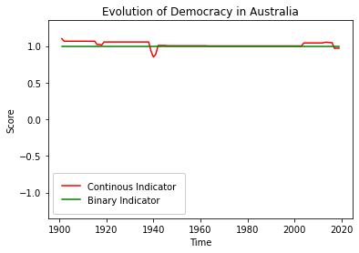

```python
is_Australia= ContinuousIndicator.country=="Australia"
Australia=ContinuousIndicator[is_Australia]

plt.plot(Australia.year, Australia.Score, 'r', label="Continous Indicator")
plt.plot(Australia.year, Australia.PredictedLabel, 'g', label="Binary Indicator")
plt.legend(fancybox=True, framealpha=1, borderpad=1)
plt.title('Evolution of Democracy in Australia')
plt.xlabel('Time')
plt.ylabel('Score')
plt.ylim((-1.35,1.35))
```

### Chile

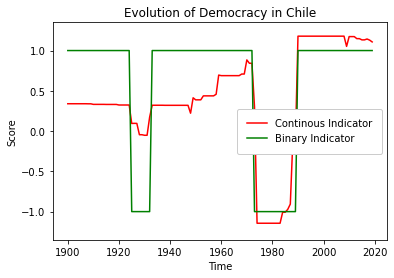

```python
is_Chile= ContinuousIndicator.country=="Chile"
Chile=ContinuousIndicator[is_Chile]

plt.plot(Chile.year, Chile.Score, 'r', label="Continous Indicator")
plt.plot(Chile.year, Chile.PredictedLabel, 'g', label="Binary Indicator")
plt.legend(fancybox=True, framealpha=1, borderpad=1)
plt.title('Evolution of Democracy in Chile')
plt.xlabel('Time')
plt.ylabel('Score')
plt.ylim((-1.35,1.35))
```

### India

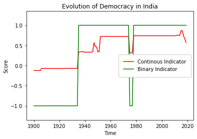

```python
is_India= ContinuousIndicator.country=="India"
India=ContinuousIndicator[is_India]

plt.plot(India.year, India.Score, 'r', label="Continous Indicator")
plt.plot(India.year, India.PredictedLabel, 'g', label="Binary Indicator")
plt.legend(fancybox=True, framealpha=1, borderpad=1)
plt.title('Evolution of Democracy in India')
plt.xlabel('Time')
plt.ylabel('Score')
plt.ylim((-1.35,1.35))
```

### New Zealand

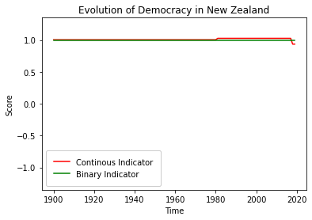

```python
is_NZ= ContinuousIndicator.country=="New Zealand"
NZ=ContinuousIndicator[is_NZ]

plt.plot(NZ.year, NZ.Score, 'r', label="Continous Indicator")
plt.plot(NZ.year, NZ.PredictedLabel, 'g', label="Binary Indicator")
plt.legend(fancybox=True, framealpha=1, borderpad=1)
plt.title('Evolution of Democracy in New Zealand')
plt.xlabel('Time')
plt.ylabel('Score')
plt.ylim((-1.35,1.35))
```

### South Africa

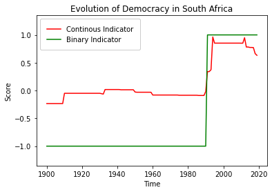

```python
is_SA= ContinuousIndicator.country=="South Africa"
SA=ContinuousIndicator[is_SA]

plt.plot(SA.year, SA.Score, 'r', label="Continous Indicator")
plt.plot(SA.year, SA.PredictedLabel, 'g', label="Binary Indicator")
plt.legend(fancybox=True, framealpha=1, borderpad=1)
plt.title('Evolution of Democracy in South Africa')
plt.xlabel('Time')
plt.ylabel('Score')
plt.ylim((-1.35,1.35))
```

### Russia

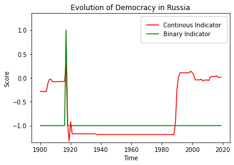

```python
is_Russia= ContinuousIndicator.country=="Russia"
Russia=ContinuousIndicator[is_Russia]

plt.plot(Russia.year, Russia.Score, 'r', label="Continous Indicator")
plt.plot(Russia.year, Russia.PredictedLabel, 'g', label="Binary Indicator")
plt.legend(fancybox=True, framealpha=1, borderpad=1)
plt.title('Evolution of Democracy in Russia')
plt.xlabel('Time')
plt.ylabel('Score')
plt.ylim((-1.35,1.35))
```

### Portugal

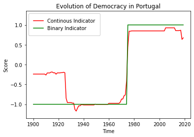

```python
is_Portugal= ContinuousIndicator.country=="Portugal"
Portugal=ContinuousIndicator[is_Portugal]

plt.plot(Portugal.year, Portugal.Score, 'r', label="Continous Indicator")
plt.plot(Portugal.year, Portugal.PredictedLabel, 'g', label="Binary Indicator")
plt.legend(fancybox=True, framealpha=1, borderpad=1)
#plt.title='Democracy in Portugal'
plt.title('Evolution of Democracy in Portugal')
plt.xlabel('Time')
plt.ylabel('Score')
plt.ylim((-1.35,1.35))
```

### United States of America

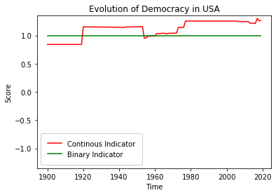

```python
is_USA= ContinuousIndicator.country=="United States of America"
USA=ContinuousIndicator[is_USA]

plt.plot(USA.year, USA.Score, 'r', label="Continous Indicator")
plt.plot(USA.year, USA.PredictedLabel, 'g', label="Binary Indicator")
plt.legend(fancybox=True, framealpha=1, borderpad=1)
plt.title('Evolution of Democracy in USA')
plt.xlabel('Time')
plt.ylabel('Score')
plt.ylim((-1.35,1.35))
```